# Population, GDP per capita and Life expectancy Analysis for Countries

Sneha Jadhav

March 11, 2021

## Background

- GDP per capita measures the value of everything produced in a country during a year, divided by the number of people. Life expectancy has increased rapidly since the Age of Enlightenment. In the early 19th century, life expectancy started to increase in the early industrialized countries while it stayed low in the rest of the world. This led to a very high inequality in how health was distributed across the world. Good health in the rich countries and persistently bad health in those countries that remained poor.
- People live longer in countries with a higher GDP per capita. Or put differently; in countries with longer lives, GDP per capita is higher. The connection between health and wealth doesn’t tell us which comes first. But one thing is clear: there are not two groups of countries, despite what many people think. Dividing the countries into two groups, developing vs. developed, is extremely misleading.
- This dataset provides data about the population, life expectancy and GDP per capita in different countries of the world from 1952 to 2007.

## Objective

- The goal of this project is to perform analysis on the GDP per capita, population, and life expectancy over the years by various continents to find exciting trends that answer some questions like has the world been shifting towards an increase in life expectancy?
- This data set includes continents and countries in two different columns, years and respective GDP, Life expectancy, and the population is stacked up in separate single columns. There are way too many columns presents in the dataset for each year and all other variables. This data is messy and non-descriptive, which has to be cleaned to make the dataset more descriptive.
- First, the raw comma-separated values (.csv) data will be loaded. Secondly, the Data Wrangling process would be carried out. Third, there will be some data exploration, and this will be completed mostly by loading plots to understand the data with visualization better.

## Importing necessary modules

```r
library(tidyverse)
library(dplyr)
library(ggplot2)
library(kableExtra)
```

## Loading the dataset

```r
gap_wide <- read_csv('./gapminder_wide.csv')
head(gap_wide,10) %>%
     kbl(caption = "Gapminder Dataset: GDP, Life expectancy and population") %>%
     kable_paper("hover", full_width = F) %>%
     kable_styling(bootstrap_options = c("striped", "hover", "condensed",        "responsive")) %>%
     add_header_above(c(" " = 2, "GDP Per Capita" = 12, "Life Expectancy" = 12,
                        "Population" = 12)) %>%
     kable_classic_2(full_width = F)
```

Gapminder Dataset: GDP, Life expectancy and population

| continent | country | GDP Per Capita gdpPercap_1952 | GDP Per Capita gdpPercap_1957 | GDP Per Capita gdpPercap_1962 | GDP Per Capita gdpPercap_1967 | GDP Per Capita gdpPercap_1972 | GDP Per Capita gdpPercap_1977 | GDP Per Capita gdpPercap_1982 | GDP Per Capita gdpPercap_1987 | GDP Per Capita gdpPercap_1992 | GDP Per Capita gdpPercap_1997 | GDP Per Capita gdpPercap_2002 | GDP Per Capita gdpPercap_2007 | Life Expectancy lifeExp_1952 | Life Expectancy lifeExp_1957 | Life Expectancy lifeExp_1962 | Life Expectancy lifeExp_1967 | Life Expectancy lifeExp_1972 | Life Expectancy lifeExp_1977 | Life Expectancy lifeExp_1982 | Life Expectancy lifeExp_1987 | Life Expectancy lifeExp_1992 | Life Expectancy lifeExp_1997 | Life Expectancy lifeExp_2002 | Life Expectancy lifeExp_2007 | Population pop_1952 | Population pop_1957 | Population pop_1962 | Population pop_1967 | … |
| --- | --- | --- | --- | --- | --- | --- | --- | --- | --- | --- | --- | --- | --- | --- | --- | --- | --- | --- | --- | --- | --- | --- | --- | --- | --- | --- | --- | --- | --- | --- |
| Africa | Algeria | 2449.0082 | 3013.9760 | 2550.8169 | 3246.9918 | 4182.6638 | 4910.4168 | 5745.1602 | 5681.3585 | 5023.2166 | 4797.2951 | 5288.0404 | 6223.3675 | 43.077 | 45.685 | 48.303 | 51.407 | 54.518 | 58.014 | 61.368 | 65.799 | 67.744 | 69.152 | 70.994 | 72.301 | 9279525 | 10270856 | 11000948 | 12760499 | … |
| Africa | Angola | 3520.6103 | 3827.9405 | 4269.2767 | 5522.7764 | 5473.2880 | 3008.6474 | 2756.9537 | 2430.2083 | 2627.8457 | 2277.1409 | 2773.2873 | 4797.2313 | 30.015 | 31.999 | 34.000 | 35.985 | 37.928 | 39.483 | 39.942 | 39.906 | 40.647 | 40.963 | 41.003 | 42.731 | 4232095 | 4561361 | 4826015 | 5247469 | … |
| Africa | Benin | 1062.7522 | 959.6011 | 949.4991 | 1035.8314 | 1085.7969 | 1029.1613 | 1277.8976 | 1225.8560 | 1191.2077 | 1232.9753 | 1372.8779 | 1441.2849 | 38.223 | 40.358 | 42.618 | 44.885 | 47.014 | 49.190 | 50.904 | 52.337 | 53.919 | 54.777 | 54.406 | 56.728 | 1738315 | 1925173 | 2151895 | 2427334 | … |
| Africa | Botswana | 851.2411 | 918.2325 | 983.6540 | 1214.7093 | 2263.6111 | 3214.8578 | 4551.1421 | 6205.8839 | 7954.1116 | 8647.1423 | 11003.6051 | 12569.8518 | 47.622 | 49.618 | 51.520 | 53.298 | 56.024 | 59.319 | 61.484 | 63.622 | 62.745 | 52.556 | 46.634 | 50.728 | 442308 | 474639 | 512764 | 553541 | … |
| Africa | Burkina Faso | 543.2552 | 617.1835 | 722.5120 | 794.8266 | 854.7360 | 743.3870 | 807.1986 | 912.0631 | 931.7528 | 946.2950 | 1037.6452 | 1217.0330 | 31.975 | 34.906 | 37.814 | 40.697 | 43.591 | 46.137 | 48.122 | 49.557 | 50.260 | 50.324 | 50.650 | 52.295 | 4469979 | 4713416 | 4919632 | 5127935 | … |
| Africa | Burundi | 339.2965 | 379.5646 | 355.2032 | 412.9775 | 464.0995 | 556.1033 | 559.6032 | 621.8188 | 631.6999 | 463.1151 | 446.4035 | 430.0707 | 39.031 | 40.533 | 42.045 | 43.548 | 44.057 | 45.910 | 47.471 | 48.211 | 44.736 | 45.326 | 47.360 | 49.580 | 2445618 | 2667518 | 2961915 | 3330989 | … |
| Africa | Cameroon | 1172.6677 | 1313.0481 | 1399.6074 | 1508.4531 | 1684.1465 | 1783.4329 | 2367.9833 | 2602.6642 | 1793.1633 | 1694.3375 | 1934.0114 | 2042.0952 | 38.523 | 40.428 | 42.643 | 44.799 | 47.049 | 49.355 | 52.961 | 54.985 | 54.314 | 52.199 | 49.856 | 50.430 | 5009067 | 5359923 | 5793633 | 6335506 | … |
| Africa | Central African Republic | 1071.3107 | 1190.8443 | 1193.0688 | 1136.0566 | 1070.0133 | 1109.3743 | 956.7530 | 844.8764 | 747.9055 | 740.5063 | 738.6906 | 706.0165 | 35.463 | 37.464 | 39.475 | 41.478 | 43.457 | 46.775 | 48.295 | 50.485 | 49.396 | 46.066 | 43.308 | 44.741 | 1291695 | 1392284 | 1523478 | 1733638 | … |
| Africa | Chad | 1178.6659 | 1308.4956 | 1389.8176 | 1196.8106 | 1104.1040 | 1133.9850 | 797.9081 | 952.3861 | 1058.0643 | 1004.9614 | 1156.1819 | 1704.0637 | 38.092 | 39.881 | 41.716 | 43.601 | 45.569 | 47.383 | 49.517 | 51.051 | 51.724 | 51.573 | 50.525 | 50.651 | 2682462 | 2894855 | 3150417 | 3495967 | … |
| Africa | Comoros | 1102.9909 | 1211.1485 | 1406.6483 | 1876.0296 | 1937.5777 | 1172.6030 | 1267.1001 | 1315.9808 | 1246.9074 | 1173.6182 | 1075.8116 | 986.1479 | 40.715 | 42.460 | 44.467 | 46.472 | 48.944 | 50.939 | 52.933 | 54.926 | 57.939 | 60.660 | 62.974 | 65.152 | 153936 | 170928 | 191689 | 217378 | … |

## Cleaning the Dataset

#### tidyr::gather() wide to long

```r
gap_long <- gap_wide %>%
  gather(key   = obstype_year,
         value = obs_values,
         dplyr::starts_with('pop'),
         dplyr::starts_with('lifeExp'),
         dplyr::starts_with('gdpPercap'))
glimpse(gap_long)
```

```
## Rows: 5,112
## Columns: 4
## $ continent    <chr> "Africa", "Africa", "Africa", "Africa", "Africa", "Afr...
## $ country      <chr> "Algeria", "Angola", "Benin", "Botswana", "Burkina Fas...
## $ obstype_year <chr> "pop_1952", "pop_1952", "pop_1952", "pop_1952", "pop_1...
## $ obs_values   <dbl> 9279525, 4232095, 1738315, 442308, 4469979, 2445618, 5...
```

From the glimpse function, We can see the observations related to the GDP. Life expectancy and population are loaded into one single column called obstype_year, and corresponding values are added into another column called obs_values. But still, we haven’t reached our end results, and the data is still untidy as the obstype_year contains two pieces of information, the observation type (pop,lifeExp, or gdpPercap) and the year. We can use the separate() function to split the character strings into multiple variables.

#### gather() and separate() to create the tidy gapminder dataset

```r
gap_long <- gap_wide %>%
  gather(key   = obstype_year,
         value = obs_values,
         -continent, -country) %>%
  separate(obstype_year,
           into = c('obs_type','year'),
           sep="_",
           convert = TRUE)

str(gap_long)
```

```
## tibble [5,112 x 5] (S3: tbl_df/tbl/data.frame)
##  $ continent : chr [1:5112] "Africa" "Africa" "Africa" "Africa" ...
##  $ country   : chr [1:5112] "Algeria" "Angola" "Benin" "Botswana" ...
##  $ obs_type  : chr [1:5112] "gdpPercap" "gdpPercap" "gdpPercap" "gdpPercap" ...
##  $ year      : int [1:5112] 1952 1952 1952 1952 1952 1952 1952 1952 1952 1952 ...
##  $ obs_values: num [1:5112] 2449 3521 1063 851 543 ...
```

```r
glimpse(gap_long)
```

```
## Rows: 5,112
## Columns: 5
## $ continent  <chr> "Africa", "Africa", "Africa", "Africa", "Africa", "Afric...
## $ country    <chr> "Algeria", "Angola", "Benin", "Botswana", "Burkina Faso"...
## $ obs_type   <chr> "gdpPercap", "gdpPercap", "gdpPercap", "gdpPercap", "gdp...
## $ year       <int> 1952, 1952, 1952, 1952, 1952, 1952, 1952, 1952, 1952, 19...
## $ obs_values <dbl> 2449.0082, 3520.6103, 1062.7522, 851.2411, 543.2552, 339...
```

With str() and glimspe() functions, we can see the data set currently has one row for every continent, country, and year combination column, which gives us more than four observations in each row. For this dataset to be tidy, we want a single observation in each row, which means a row should consist of a continent, country, year, population, GDP, and life expectancy in that year.

According to the tidy data rule, each tibble should contain information about a single type of observational unit in the dataset. Still, in our dataset, we have a combination of lifeExp, pop, and gdpPercap stored in the same “obs_type” variable. This is a violation of a tidy dataset because these values each represent different types of observations.

So transforming the dataset from a wide data set with a column for every year to a long data set that has all the above-mentioned colmnsns i.e, continent, country, year, lifeExp, pop and gdpPercap columns.

```r
gap_long <- gap_long %>%
              spread(obs_type, obs_values) %>%
              select(continent, country, year, lifeExp, pop, gdpPercap)
glimpse(gap_long)
```

```
## Rows: 1,704
## Columns: 6
## $ continent <chr> "Africa", "Africa", "Africa", "Africa", "Africa", "Africa...
## $ country   <chr> "Algeria", "Algeria", "Algeria", "Algeria", "Algeria", "A...
## $ year      <int> 1952, 1957, 1962, 1967, 1972, 1977, 1982, 1987, 1992, 199...
## $ lifeExp   <dbl> 43.077, 45.685, 48.303, 51.407, 54.518, 58.014, 61.368, 6...
## $ pop       <dbl> 9279525, 10270856, 11000948, 12760499, 14760787, 17152804...
## $ gdpPercap <dbl> 2449.0082, 3013.9760, 2550.8169, 3246.9918, 4182.6638, 49...
```

In the summary we can see the dataset is tidy now and each observation and variables have seperate rows and coloumns.

```r
summary(gap_long)
```

```
##   continent           country               year         lifeExp
##  Length:1704        Length:1704        Min.   :1952   Min.   :23.60
##  Class :character   Class :character   1st Qu.:1966   1st Qu.:48.20
##  Mode  :character   Mode  :character   Median :1980   Median :60.71
##                                        Mean   :1980   Mean   :59.47
##                                        3rd Qu.:1993   3rd Qu.:70.85
##                                        Max.   :2007   Max.   :82.60
##       pop              gdpPercap
##  Min.   :6.001e+04   Min.   :   241.2
##  1st Qu.:2.794e+06   1st Qu.:  1202.1
##  Median :7.024e+06   Median :  3531.8
##  Mean   :2.960e+07   Mean   :  7215.3
##  3rd Qu.:1.959e+07   3rd Qu.:  9325.5
##  Max.   :1.319e+09   Max.   :113523.1
```

## Data Visulatizations

Calculate and plot the the mean life expectancy for each continent over time from 1950 to 2007.

```r
continents <- gap_long %>%
  filter(year > 1950) %>%
  group_by(continent, year) %>%
  summarize(mean_le = mean(lifeExp)) %>%
  ungroup()
```

geom line plot

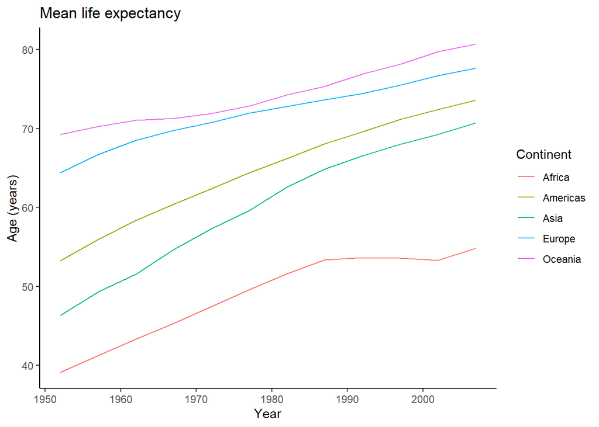

```r
ggplot(data = continents, aes(x = year, y = mean_le, color = continent)) +
  geom_line() +
  labs(title = "Mean life expectancy",
       x = "Year",
       y = "Age (years)",
       color = "Continent") +
  theme_classic() +
  scale_fill_brewer(palette = "Blues")
```

Filtering data by year 2007 for further visualizations

```r
gap_long_2007 <- gap_long %>%
  filter(year == 2007)
```

Plot the geom_point plot to show the relationship between GDP, population and life expectancy in world

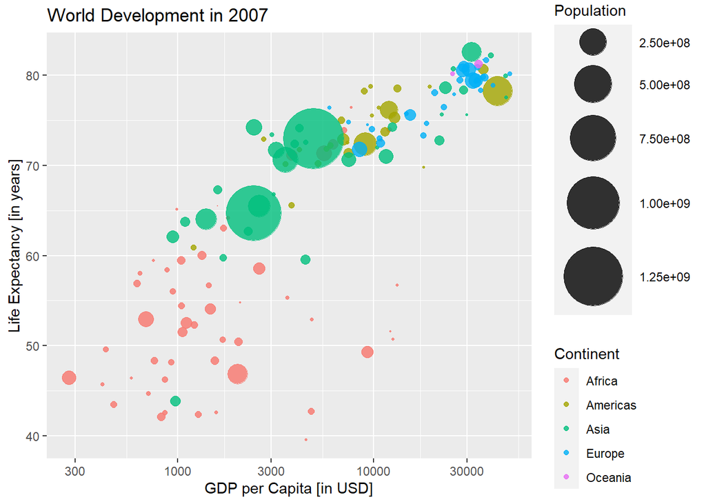

```r
ggplot(gap_long_2007, aes(x = gdpPercap, y = lifeExp,
                          color = continent, size = pop)) +
       geom_point(alpha=0.8) + scale_x_log10() +
       scale_size(range = c(.1, 20), name="Population") +
       labs(x = 'GDP per Capita [in USD]', y = 'Life Expectancy [in years]',
       title = "World Development in 2007", color="Continent", size="Population")
```